# Crestview Strategy Data Science - Media Monitoring

[figure not shown]

[figure not shown]

### Google Search Trends

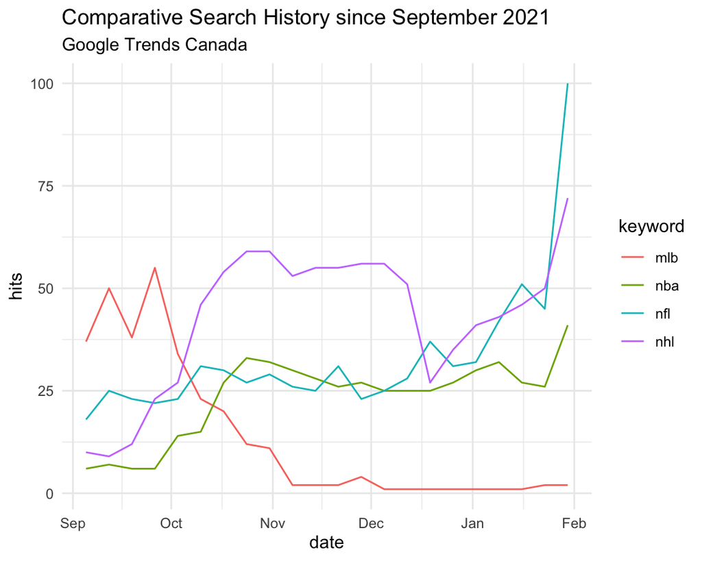

### Twitter Issue Sentiment

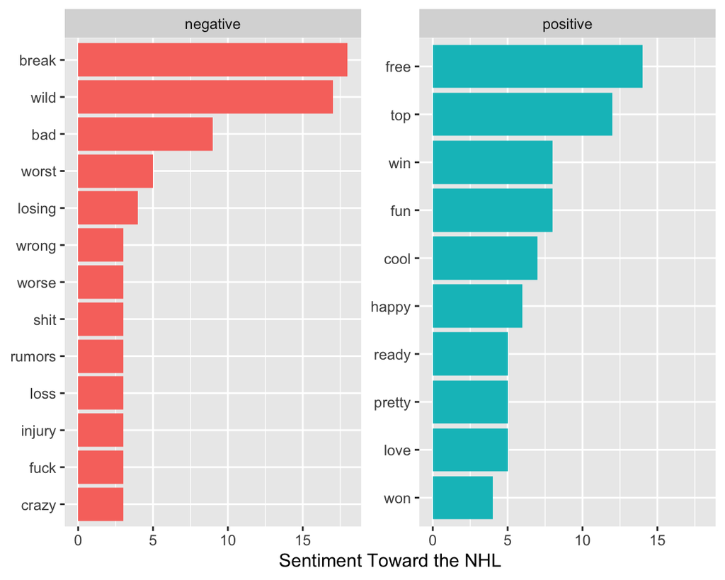

### Latest Tweets

screen_name

text

402SportsBets

NHL ytd 143-147-1 -17.92u

Det ml +110 Wild ml -165 https://t.co/P3UaJSA5Bp

SportsGuyEvan

We’re getting ready to bring out the brooms again tonight 😤

#NBA Grizzlies -4 Cavs -5

#NHL Wild in Reg

#CBB Arkansas -10.5 Xavier/Butler o129.5

Carl_D_Pedersen

@faouzia Congrats on the NHL All Star anthem gig. Looking forward to your performance!

Hottie4Sports

Jason Sharpe

8-Unit NHL Game of the Year

Los Angeles -135

OfftheRailsPod2

Flow Giroux&gt;&gt;&gt;&gt; Beard Giroux https://t.co/eoqzNRuvE1

rick_tidwell_

@pmagic17 @NHLFlames @NHL Book it

B2B_Soccer

@tesh901 @PrimeRoyce @samstejskal Definitely recall seeing the NHL game outside in Minnesota had videos of frozen beer so quite possibly.

AR_NHL

This is the Official Account of AR#8853.

younghoff4real

@FriedgeHNIC Lol. No wonder the NHL has shitty content. Why would they not hire Biz for that role 😂😂 @BizNasty2point0

hometownhockey_

You got it, Canada!! 🚨To celebrate @NHL All-Star, we’re giving a lucky fan the chance to WIN a signed jersey from @MapleLeafs goaltender Jack Campbell! 🥅

✅ Nickname: Soup ✅ Number: #36

Enter now ➡️ https://t.co/ZL34HQ5bn0

@Rogers #HometownHockey https://t.co/cGmck30s4i

bobano

All Sports (Best Value!) Monthly: $75 3 Months: $200 6 Months: $400 1 Year (All Sports 2022): $750 All Sports include #NFL, College Football, CFL, #NBA75, College Basketball, NHL, MLB, UFC

Profitable YTD NHL &amp; #NBA75, 65-37 64% CBB streak

E-Mail bobano350@gmail.com to subscribe https://t.co/9RUVLg05kI

bobano

606-555 52% +12.2 Units NHL YTD after a profitable Tuesday night last night on the ice!

bobano

Cash The Ice Guys @The_IceGuys NHL Hockey betting show presented by the @hockeypodnet Tuesday Best Bet with #LeafsForever / #NJDevils Over 6.5

Tune in 7 days a week for the best, most in-depth NHL betting show anywhere and the only show breaking down every single game all season

bobano

Ian Cameron Capping E-Mail Service

NHL Monthly: $50 NHL Season: $200

#NBA75 Monthly: $50 #NBA75 Season: $200

NHL &amp; #NBA75 Season Combo: $350

CBB Monthly: $50 CBB Season: $100

E-Mail bobano350@gmail.com to subscribe

seanshilinsky41

@BRob61048292 @BlindNewSpeak @HMS_Puckett @CPhilbin7 @bretpatrick12 @HabbyMomma @NJDevils @NHL I thought so.

seanshilinsky41

@BRob61048292 @BlindNewSpeak @HMS_Puckett @CPhilbin7 @bretpatrick12 @HabbyMomma @NJDevils @NHL Don’t thank me. Just take normal pictures. Who the fuck takes a picture in a bathroom thinking hey this pic will look pretty cool? Do you think women are really gonna think you look good in that pic? It’s weird man.

seanshilinsky41

@bretpatrick12 @BRob61048292 @BlindNewSpeak @HMS_Puckett @CPhilbin7 @HabbyMomma @NJDevils @NHL If only what you said in any of that was true it’d be funny…. Nice fail though squirrel.

terryjt1

@visotto1 @NHL @espn @ABCNetwork @Sportsnet They’re all better than Brady

ConnorTheLeafs

@300furrybears @NHL @espn @ABCNetwork @Sportsnet @MGMResortsIntl I don’t know if that can be answered

bohm_matt

@ChrisBohm99 Don’t think they could of went with red wings because of the Detroit Red Wings NHL team. Red Wolves would of been awesome.

TheOfficialMrA1

@PR_NHL There we go now they remembered panarin

Travis_Bulger

@Breezingbee21 @NHL_On_TNT @mnwild Kap is on 11 game point streak as well I believe

jabo_vancouver

Just out of curiosity will you be watching the #NHL All Star game this weekend?

KMaherNews12

You know what shows more dedication than buying a jersey? @IslesHistorical @islessignguy @IslesGirl3 @ExIsledUsher @NYIslanders #Isles @Barzal_97 #NHL https://t.co/i8dDiOKO0X

tmilrealdeal

First #NHL wagers of the year worked out nicely. 2 for 3 on a Tuesday.

✅Rangers ML (+140)Money with wings ✅Flyers ML (+140)Money with wings ❌Sabres/Golden Knights UNDER 6

Wednesday’s picks posted soon. #FollowMeToTheMoney 🤑 https://t.co/8e9eqVe8AF

DTH_Mason

killing the NFL draft would be a massive loss to pro football.

Its become an event that a LOT of people follow closely. You don’t get this in the NBA, NHL, or MLB. The NFL Draft is special. https://t.co/e7bOivy80E

JackVV03

@NHL Today we mourn

carmody_jackson

@1jackpott congrats to the first of many https://t.co/9fMO78jPLF

jackson_mnslp

@NHL_On_TNT @mnwild GO WILD! Bright future

ifstonefan

Probably more fun to watch then 1/2 of the @NHL games most nights… https://t.co/yDcGNarZNj

RJM53179

@NHL @espn @ABCNetwork @Sportsnet @MGMResortsIntl How is the best goaltender in hockey not on the all star team ? Ridiculous https://t.co/hIHI88zwX6

bernier_matt

#NHL Bets for Feb. 2

https://t.co/eEEtMPZk78

BuckeyeMafia

@BetMGM MLB: Jeter NBA: Cleveland Kyrie i guess NFL: Matt Ryan?😭 NHL: no clue

LeafsAllDayy

@NHL @espn @ABCNetwork @Sportsnet @MGMResortsIntl Better than Price

PicksKrob

A great start to the year going 156-141-6,and +40.34 UNITS in ONE MONTH!! My $100/unit clients made $4,034 in January!! The free month of picks is up but DM me to get picks every day for a cheap price!

#GamblingTwitter #gambling #nhl #nba #mlb #nfl #CBBPicks #CBB

TorontoStar

With NHL All-Star weekend officially marking the midpoint of the season, there’s plenty to talk about. Join our @TwitterSpaces to ask a question or join in on some hockey talk with @reporterchris.

Tomorrow at 6 p.m. ET: https://t.co/FwaQjDbqhQ

GoBuffs2204

Folsom Field would be the best venue possible for the Winter Classic. Avs vs Wings. Make it happen @NHL @Buccigross https://t.co/VeuorHlSIM

300furrybears

@NHL @espn @ABCNetwork @Sportsnet @MGMResortsIntl American goalie, American goalie, why does the US have better goalies than Canada does right now?

gzul

@SkrticX @Cleveland_PL @thiswascle @EncyCle_ The Cleveland Barons of the AHL were the Montreal Canadians of the NHL during the Freddy Glover years

MinorMidgetGTHL

@WatchMyReview He would be the Leafs 3rd best D.

So you figure out what that says about Leads D Core.

And as always.

NO NHL PLAYER is shit. OMG

TelnoffJr

@xwleblancx @CaleBenter14 I saw it first from the official nhl account

xLuckTV

Gotta get it pretty close.

#pcgaming #xbox #playstation #nhl #nhl22 #hockey #goalie #player #tendy #gloves #hockeynight #pro #hut #videogames #twitch #smallstreamer #drunk #pga #golf #golfer #pga2k21 #golflife https://t.co/WPZLSZv5fX

AugustYoungWins

My Wednesday Premium Card @DocsSports is stacked!

&gt; https://t.co/fI95Hs5V5y

#CBB - “7” selections including a 6-unit best bet!

#NBA - “3” selections including a 5-unit best bet!

#NHL - “1” selection as we look to build on our +6,805 winning season!!

LFG!!

LocksTitan

02/01/22 Recap: 🏀 NCAABB: 1U Iowa St. +1.5❌ 1U S Carolina +8.5❌ 1.5U Kent St ML💰 🏒 1U Rangers ML (+130)💰 1U Devils U6.5❌ 1.5U Sharks O5.5❌ 1.5U Sens U6💰 2.5U Jets ML❌

Rough day but today is the last day for NHL before the all star break. Let’s lock in. -3.75U https://t.co/iR1eN7lpZJ

CowPacific

@yanoforsure Hasn’t it been 29 years that the NHL has tried to make hockey in Arizona work? Just sayin’.

lfgmszn

@NHL @espn @ABCNetwork @Sportsnet @MGMResortsIntl igor should be all star too if you didn’t know

texas_grande

This aged well, also why I am not an NHL GM I guess 😂😂 https://t.co/C9ISxBfNID

JJinTLH

@AuburnMBB When are we getting one of those NHL type court projected starting lineup intro’s?

mtkmurph

@hometownhockey_ @NHL @Rogers Jack Campbell Toronto Maple Leafs

RotoWireNHL

FanDuel NHL: Wednesday Targets https://t.co/Q5Pw7mDHpz

JAGD94

@JohnNyrs1994 @NYRangers @WolfPackAHL Jones looks good he moves the puck fast and that’s what the D Men of this current NHL are asked to do. Honestly thought Barron was a little invisible the last 2 games. This GG shortened the bench last night. I know he did with the D.

styler12

@hometownhockey_ @NHL @Rogers Jack Campbell Toronto Maple Leafs https://t.co/DDqiW4P51U

numberFire_NHL

NHL Daily Fantasy Helper: Wednesday 2/2/22 https://t.co/XDPwRiDq71

NHL

Jack Campbell — first time #NHLAllStar, full time brick wall. 🧱

Don’t miss #NHLAllStar Weekend on @espn, @ABCNetwork, &amp; @Sportsnet on Feb. 4th &amp; 5th!

Presented by @MGMResortsIntl https://t.co/lpGQRVMcgP

NHL

#NHLAllStar Timeline: Claude Giroux (@28CGiroux) Edition 🧡

Make sure to watch #NHLAllStar Weekend on @espn, @abcnetwork, &amp; @sportsnet on Feb. 4th &amp; 5th! https://t.co/iFs0RWMvsa

Margefro87

@Mearlzz @NHL @espn @ABCNetwork @Sportsnet because it’s literally the last three winners by year…

Don_inFarrhaven

Annual LOL at the NHL for virtually shutting down for a week (with the exception of the least watchable game on the calendar) while the NFL shuts down for a week. Brilliant.

gramnorth

@MikeGrinnell_ How many outdoor games have the bruins and penguins played in? Seems like the same recycled garbage @NHL puts out every year.

fiyahpowah

So the Washington DC area has 4 major sports teams: Capitols (NHL) Nationals (MLB) Wizards (NBA) Commanders (NFL)

Not the most creative or motivative slew of team names imo.

BryanDJames

@noblerzen They couldn’t do Redhawks because of the NHL team and Redtails would still have racial connotations that not everyone would be ok with. I liked Red Wolves and don’t buy that there was any trademark issues–I think Snyder was intent on military glorification. Sigh

DrWeiliZhang

@NHL @espn @ABCNetwork @Sportsnet So you didn’t want players to quarantine for the Olympics but you going ahead with the all star game, don’t pretend it’s about player health and safety.

thepuckers99

Dominique Ducharme reveals how Carey Price welcomed him as a coach https://t.co/jp0reETl16 #NHL #Hockey #HockeyTwitter https://t.co/RHd8JuQLxv

thepuckers99

The Golden Knights are in a tough spot with Jack Eichel https://t.co/MyAUB88EIS #NHL #Hockey #HockeyTwitter https://t.co/gCFhjFqsiC

JohnnyKasudluak

@NHLBlackhawks gamedy? Like Remedy. Let’s Gamedy the Situation. 😎 #GAMEDAY #NHL https://t.co/5cXVkY9Sq7

JeffSammut

.@SXMCanadaNow at 1pm ET on @SXMCanadaTalks! @ArleneBynonShow #TruckersForFreedom2022 #ErinOToole, author @BraveWriter on “Raising Critical Thinkers”, @zwoodford’s weekly visit, @Lesleyscorgie w/advice for potential female entrepreneurs, a look at every Canadian @NHL team &amp; more! https://t.co/3hZe2M1E6n

seanshapiro

Jaromír Jágr is going to be one of the guests on tonight’s NHL on TNT broadcast.

manutd2416

I actually don’t mind the @nhl skills competition but should the $30k prize not goto a charity of the players choice rather than the highest paid players in the league

diebytheblade

In case you missed it last night, Buffalo’s road trip ended on a sour note in Vegas. @wolfebltd takes a look back at the game. https://t.co/7TlzBI5omp

Hughes70Rob

@CMDeDominicis Do the Sabres have nobody in the organization that sees this? I never understood how anyone with a computer can figure this out but billion dollar operations ( nhl teams) cant

heyitsloreto

@hometownhockey_ @NHL @Rogers Jack Campbell, Toronto Maple Leafs. #LeafsForever #HometownHockey

rvdnsx

@omgrodnick @NYRangers @WolfPackAHL But no NHL games for the next two weeks.

lunaterraluna

@TheBluPea @terra_money …and NHL 👎👎👎

HBressette19

So why can’t OHL and NHL and Raptors have 50% capacity now like you gave Bingo halls and casinos and every grocery store in ontario. They are allowed to have more than 500….who even came up with that number. Rink with a capacity of 5000….could certainly separate 2500 fans https://t.co/9HmBrSbRvc

KobeYukon

@NHL Which one means yes? #Robinhoodmenintights

GriffDoggDFS

New Video 🚨

DraftKings - NHL Picks (2/2)

📺: https://t.co/GSwICMW2KM https://t.co/JIrnHWK2WM

jtlope

@SDPNLCS2022 Doubt the NHL expands again for at least 10 years. Coyotes are heading to Houston if nothing gets worked out in Phoenix.

jtlope

@SDPNLCS2022 Which is a reason why the NHL wouldn’t want to expand. AHL, as a development league for the NHL is better for both of the quality of play is high.

jtlope

@SDPNLCS2022 If it is good for business. NHL at 32 teams is a good number that they will keep for a while. Though I would like the Coyotes to stay in AZ, I think they eventually end up in Houston.

thegamblingcorn

NHL Slate is not a great one, i think im gonna wait to drop the parlay until after the all star break since tonight is the last night of hockey. After i put out my plays of the day and you guys still want a parlay i will cook something up.

thegamblingcorn

NHL Plays Of The Day:

Wild ML -165 Kings ML -130 Flames/Yotes O5.5 -120 @SurgicalStream @BookitWithTrent

Beer_Dingo

@hometownhockey_ @NHL @Rogers Jack Campbell Toronto Maple Leafs #HometownHockey

klondikesue

@hometownhockey_ @NHL @Rogers Jack Campbell Toronto Maple Leafs

IBTheGR81Gaming

Hopefully life makes a turn like this soon! Go for a pass back and score!

#gamer #nhl #gamerdad #hockey #smallstreamer #TwitchStreamers https://t.co/hdlUATA3CX

bot_nhl

@jonah_mull The Boston Bruins have traded Brent Burns to Carolina for Alex Pietrangelo and a 3rd round pick

bot_nhl

@arm_kaewpuang Auston Matthews has signed with the Minnesota Wild: 7 years, $2M per year.

bot_nhl

@arm_kaewpuang Loui Eriksson has been suspended 3 games for boarding Filip Forsberg.

bot_nhl

@arm_kaewpuang Evander Kane is retiring after this season

bot_nhl

@c_sukitch Semyon Varlamov has been traded to the St. Louis Blues in exchange for a 2025 3rd round pick

bot_nhl

@N8_wil Travis Konecny has won the Art Ross Trophy

bot_nhl

Jesperi Kotkaniemi has been traded to Los Angeles for Sebastian Aho, a 2024 2nd round pick, and a 2024 2nd round pick

bot_nhl

@jonah_mull The Calgary Flames have claimed Andrew Mangiapane off waivers from Florida.

HabsBeard

@lunchbox_23 while also maintaining some extra cap space to build around then still. You basically get punished for drafting and developing well in the NHL lol.

HabsBeard

NHL should implement a luxury tax like the NBA. It’s crazy to me the advantage that some lower revenue/money losing franchises have over the top revenue driving teams in the NHL. Also the cap needs to be adjusted for every team to better allow them to keep their players.

RyanVeneman1

@BetMGM Matt Ryan, Kawhi, NHL isn’t real, and jeter

LMonkey11

Teaching the boy #streethockey on ice @NHL #Colorado https://t.co/Y0G5A9fTaB

RvaLock

Here’s our Wednesday Night Slate 🍽️ #GamblingTwitter

NBA🏀

2U Grizzlies -4 (-110) 2U Cavs -5 (-110) 2U Nets -4 (-110)

CBB🏀

2U Kentucky -15 (-110) 2U Purdue/Minnesota O139.5 (-110)

[output not shown]

rbrobbi

@BenPopeCST Some Defensemen can get away with reckless pinching in the AHL using their speed, makes em look like offensive defensemen. When they get to the NHL they get vaporized by good teams.

xbaggypants

#NHL Picks &amp; Plays Februray 2, 2022 https://t.co/vpAZB2YmEq

An_DrewLevy

Mix blue &amp; gold, what do you get? Roman Josi #Preds

2x #NHL All⭐️ https://t.co/clmTkPSt7q

RonBohning

Panthers set up for ‘good final stretch.’ Where things stand heading into All-Star Break https://t.co/LdGA3E17XL https://t.co/toBAng9iOL

trans_rumor

Senators mid-season review: Strange first half a mix of player highs, team lows https://t.co/24HVTWfD3k #NHLRSS #NHL #OttawaSenators #sportsnetca

jon_dubs393

Lmao the NHL is dead to me. https://t.co/MqFSarhRnZ

shimmy_the_pole

@ntrider825 For everything the NFL gets wrong (it is a league rivaled in stupidity only by the NHL), at the very least it can hang its hat on getting their draft structure right

GeoffBakerTIMES

View of the New York City skyline out my plane window a few minutes ago. #SEAKraken #NHL #Kraken https://t.co/hRlaTLIo0R

trevesius

@CodyBush14 @94AndreRBryant @JuiceSimps0n @mrwright7 @AdamSchefter You don’t have to like it. 2 games in the nfl is a lot. It’s equivalent to 20 in the MLB or 10 in the nba or nhl. All of this is not the point though. I simply disagree that he took over a team ready to win, he made them win IMO.

gordie1982

@hometownhockey_ @NHL @Rogers Jack Campbell Toronto maple leafs

DrewVanDrese

One of my favorite parts of every @umichhockey season is the @USAHockeyNTDP exhibition.

The NTDP has done wonders for USA hockey’s development; love any look at the players who will be this summer’s NHL draft picks and next year’s top impact freshmen for #CollegeHockey. #GoBlue

toshanshuinLA

noted devils clown retweets this praise of his article about how the rangers are actually bad during the 1st period of rangers/panthers, proceeds to go completely silent for the next two periods while the rangers outplay the best team in the NHL 🥴 https://t.co/LPno7ixCm0

torontobaghead

Kadri for scraps was voted the worst #LeafsForever trade of the decade last year.

With Kadri’s superstar turn, we are forced to ask:

Was the Kadri trade the worst NHL trade of this century? Was there a worse trade between 2000 and 2022? https://t.co/BLssRG8Wrc

billsuth35

@DanyAllstar15 I’m not a hater, but it feels like NHL officiating is at an all time low. Somewhere between abysmal and random number generator.

RecretionCanada

Watch Live: Canadiens’ Carey Price speaks to media for first time this season https://t.co/oscflsXPdA

buffsportznut

@c22dope @MaddyHudak_94 @BuffaloBills the Pegulas own the team and @KimPegula is not only a strong, educated, and hands-on owner of this team and the NHL @BuffaloSabres , she’s an American of Korean descent. @Broncos are owned by a Trust, which is an entity.

MannyTerrebonne

@dickinson_shawn no dude….you need the yanklees and red sox and dodgers and cubs…thats all…viallans…parody is a disaster…hurt the nhl ??? its ratings are a disaster ! mLS teams are now worth more then alot of NHL teams…open your eyes….

MannyTerrebonne

@dickinson_shawn nhl needs superteams…#leafs #habs #NYR #flyers #kings …all the best players go there and to hell with lux tax implications…it works for the nba…it just drives interest…

justinwinston22

Hockey fights are probably the most entertaining things to watch on the planet. What other sport thats not boxing or MMA are u allowed to throw hands MID games, and not get suspended for it?!😂😂🔥🔥 #NHL

45Slats

NHL 02-02 adding: Islanders regulation -110

KrauseArik

@sddavis63 @worldhockeyrpt It’s still one of the biggest viewership draws for the NHL on a yearly basis. It’s going nowhere.

The “gimmick” crowd is a very small minority.

jonjerkone

@NHL @espn @ABCNetwork @Sportsnet Oh is it almost the @NHL all star game. https://t.co/lFMpTu7a1P

BettingPLC

SOGGY Model plays⬇️

Like these solo in addition

Draisaitl Backlund Kuznetsov Eriksson Ek Doughty Iafallo

Also added a parlay w/o Brock under +1250

Can’t believe we missed on a stat correction last night…still hurts, but gotta move on

#NHL #GamblingTwitter #bettingpicks https://t.co/aA0okVXI4F

TroyMcD74

@hometownhockey_ @NHL @Rogers Jack Campbell Toronto Maple Leafs

BrandonHaddrel1

@Sportsnet650 @SadClubCommish Hey guys Brandon in Langley here.Regarding Petterson,I ran some numbers based on body Weight for the top 20 centers in the NHL. The league average based on these 20 centers came back at 206lbs.Petterson weights 164lbs which is almost 50lbs less than league average. Thoughts? Thx

17tylersanders

@ItzLamarSZN @NHL @28CGiroux @espn @ABCNetwork @Sportsnet Some are from my dad and some I chose. 3 outa 4 are good

17tylersanders

@ItzLamarSZN @NHL @28CGiroux @espn @ABCNetwork @Sportsnet You a bandwagon bro. How u a lakers and penguins fan?

BetMGM

It’s 2/2/2022.

Who’s the best player to wear #2 in each of these sports:

NFL: NBA: NHL: MLB:

Hoops227_NFL

https://t.co/NJCCG2RUBr Bets NBA and NHL Picks for February 2, 2022 https://t.co/NrTKifeut6 https://t.co/v6vxXFGGY0

rebe_gary

@DavidLCreme @MikeBraves2579 @coopster2u @jemelehill @NHL @NFL Right bc it “must be tough” to watch the NFL and not see enough black coaches. How do you carry on in life? The oppression must be overbearing

shawnnhl

@hoagsxxx Yeah, he’s hit or miss. I like his passion and actually don’t mind him being a homer. But I hate when he says random shit that doesn’t make any sense.

However, I’d say over 2/3 of the broadcast teams in NHL are horrendous and can put you to sleep. I’ll take Jack over that.

RonKuchler

@BlueshirtsBreak The other thing to keep in mind is the length of the NHL season compared to College and Juniors. Giving them a break keeps them fresh for a season longer than they are accustomed too

jetkrzy

Something rarely if ever, found in the NHL. https://t.co/xntigwpoXB

petekowollik

@NHL @28CGiroux @espn @ABCNetwork @Sportsnet Not a single ring

REALTORdotca

What’s not to love about #ldnont?

Fan of 🎭? There’s @thegrandlondon. Fan of 🏒? “It’s like a mini NHL” at @londonknights games. Fan of 🛍️? Check out @CoventGardenLDN.

Learn more on https://t.co/0nnKqiuyGq Living Room: https://t.co/RjPEdDyJyX https://t.co/VIqbhcruDz

jack06yeo

@elijahburke138 @NHL Damn right

arm_kaewpuang

@bot_nhl @PrincipalP_ this is tragic

arm_kaewpuang

@bot_nhl @MitchBrodie_ it’s doubling down

MunchoJ

WHOS READY FOR ANOTHER BANGER NHL PLAY 🔥🔥

Like this up if you want it #GamblingTwitter

MunchoJ

Potentially one more NHL today

Flames on a back to back? Don’t care, they have a god in Gaudreau on the team - LIKE IF YOURE TAILING 🔥🤩 #GamblingTwitter https://t.co/jROaEKFkzS

omgrodnick

@rvdnsx @NYRangers @WolfPackAHL They could just let Laf keep playing top line minutes and scoring in the NHL

omgrodnick

@bill_goldthorpe @SammmyStern Not saying it is. But there is a North American bias in the NHL. Braden Schneider was playing against children before he came to Hartford. Nils was playing in a men’s league.

I would think there’d be a bigger adjustment for a kid from bumblefuck Saskatchewan coming to NYC.

loscprono1

🏒💰 AVIS SAFE NHL 03/02💰🏒

⏮ Minnesota Wild victoire

#TeamParieur https://t.co/5uYeNq05bW

DrGlayer

Couldn’t agree more, enough of the Leafs, Jays, Raptors, NHL, NFL bullshit. Take a hike. Shameless selfish people who are supported by dirty politicians. https://t.co/PEFGHkTAkk

xJashh

Hey other NHL teams. Look at JvR he’s so valuable. We would hate it if someone sent us a consider offer for him. https://t.co/yjWNTkVsiu

*TEdge*

@NHL @espn @ABCNetwork @Sportsnet Chara had 108.8 but okay

GlennBoB69

@PR_NHL Can someone please tell me who decides where games should be blacked out? I am a 14 hour drive from Ottawa and all their home games are blacked out. Last night their away game in NY was blacked out. This needs to change. #nhlblackouts #nhlapp #notfair #goisles

sarah052794

Filthiest Goals of January | 2021-22 NHL Season https://t.co/7EuXEQamia via @YouTube

ScarletKitty

@hometownhockey_ @NHL @Rogers Name: Jack Campbell Team: Toronto Maple Leafs #hometownhockey @hometownhockey_ @Rogers #LeafNation #soup

dogandwinelover

Filthiest Goals of January | 2021-22 NHL Season https://t.co/r1DkIJSWWS via @YouTube

srodin_77

Check out todays Podcast, which is free and available on all platforms but also on YouTube! Subscribe and follow to the pod for your fantasy hockey and betting needs 🔥💰 #NHL #bettingtips #bettingsports #fantasyhockey https://t.co/8KgWJfagkP

oysters1312

@MikeSalvo_ @NHLFlyers @28CGiroux @ryannegiroux This picture is extra funny because Sidney Crosby is a 3x Stanley Cup champion and the Flyers haven’t won a cup since 1975 and have the 7th least points in the NHL.

JustinCostea

@hometownhockey_ @NHL @Rogers Jack Campbell Toronto Maple Leafs

Sportsnet

The Ottawa Senators have a five-day All-Star break to reflect on what was surely the strangest first half of a hockey season in franchise history, writes @HockeyScanner. https://t.co/KRTyxbYeRE

banjorman

@thistwinsfan @mnwild @NHL_On_TNT @KFAN1003 It’s not fun doing something that’s not unique to our team, honestly. I hear you. But at least shout is specifically unique to our team.

dan_dssox

@Capitals @NHL_On_TNT Let’s go caps!!! 🥅🏒🥅🏒

hlamp

Panthers set up for ‘good final stretch.’ Where things stand heading into All-Star Break #SmartNews #TimeToHunt https://t.co/YUlam0X12K

topfanscorner

New Era Chicago Blackhawks NHL 5950 59FIFTY Fitted Cap Hat - 7 3/8 Rating:🌕🌕🌕🌕🌑 $119.99 👍 https://t.co/W4drRqqGFD https://t.co/4oFEg4z7Fy

scarletvwitch

Claude Giroux losing his hair through the years https://t.co/z94ZQ8mx4x

nhl_tradetalk

Defenseman Tyson Barrie is back from injury and will play Wednesday night as the Edmonton Oilers take on the Washington Capitals. https://t.co/JQGgMn42CB

nhl_tradetalk

Instead of trading J.T. Miller, there is talk of the Vancouver Canucks trading other players to make room for a Miller extension. https://t.co/sXZfs6GB7u

mahaffy_rachel

@hometownhockey_ @NHL @Rogers Soupy…Toronto Maple Leaf’s Jack Campbell

inside_the_rink

Panthers Enter All-Star Break as NHL’s Most Dominant Team #NHL #TimeToHunt https://t.co/ilfZhmYEnJ

kenmoorealberta

I don’t know if Kane is guilty of all the misconducts which have been levied against him but I think he’s guilty of extremely poor conduct in many cases and not one I’d like my child to see as a role model. Here is some background on Kane. https://t.co/ykJKANFtuT

BrianCohen1979

@coopster2u @jemelehill @NHL @NFL So stop playing…….FFS. Why does everything have to be some sort of representation of race, gender, etc.

If you don’t like it, stop supporting it.

MikeFerrari13_

@MrPodz @31Shesterkin @NHL Very unlikely between the 13 game road trip to start the year and being the first team to get covid and taking the league a while to shut the games down for us we dug a huge hole

c_sukitch

@bot_nhl which sebastian aho

oilers49er

@GGreensmoke @Bob_Stauffer Nuge on the PP in a shooting position even though he’s a passer. Shore is the worst PK player on the team, with a team that has 7 other PK players. These are signs that you’re a bad coach and there are plenty of bad coaches in the NHL.

Nobody is scared of Kassian.

davey7163

@davehodge20 Instead of 3-on-3, go back to 5-on-5, or try 4-on-4 … don’t care for the NHL all-star game anymore

Habzfan12

@LordChanky123 @newheights24 @NHL For that🙄

SpilFiasco

@ntrider825 Id also have to think barring huring Doug Marrone NFL has ti be the hardest to intentionally lose without being obvious. To many variables where NBA and NHL teams get away with it

jgwitz

@rmnb Copley. He’s a capable experienced NHL backup

MontrealLFC

Hey @goOilers_go - Happy 10-year anniversary of probably the highlight of your NHL fandom life!

Erdely25

@PR_NHL @penguins Could’ve tagged the man @68Jagr

rreardon06

@hometownhockey_ @NHL @Rogers Jack Campbell and Toronto Maple Leafs 💙🤍

blueshirtblog_

@NYRangers @StrangerRangers @WolfPackAHL Send Hajek down too, the more he plays maybe he’ll get better. Send McKegg down to while ur add it so he can clear waivers and play 4th line AHL minutes instead of 4th line NHL minutes

leftsideheavy_

🚨Episode 81 Ft. @Haydn_Barton🚨 NHL News and NFL Championship Weekend!

**~ Joe Brrr**

MGK

Patrik Allvin hire ++ MORE

*Episode was recorded prior to Brady retirement*

Presented by: @BlueWireHustle

LISTEN, WATCH, &amp; FOLLOW ⤵️ https://t.co/OWrfxjOLrn

#NFL #NHL #Canucks https://t.co/Wjsk213Hpr

f4denz

OK, I have to consider that US Soccer is comparing the World Cup qualifier to the NHL Winter Classic held in MN this year. Yes please show me a single hockey player that didn’t have 4 layers of clothing and let’s not talk about the many cases of frostbite that happened that day

bretpatrick12

@BravesStanSzn @HabbyMomma @BlindNewSpeak @NJDevils @NHL Thank you Eugene for your insightful comments, but I thought of Nazi flag when I saw it old man. If you didn’t, so be it. It’s perception, who cares?

BellyUpPodcasts

LIVE NOW! Phired Up @phireduppodcast #StreamingLive on https://t.co/ACjPPzuApr recapping the Conference Championship weekend, #Sixers trade targets, &amp; HOF baseball debate! #NFL #NBA #NHL #MLB #NFLTwitter #NBATwitter #Sports @BellyUpSports @tikiLIVE https://t.co/ACjPPzuApr https://t.co/ePymvgx25u

Wentzlyvania1

@go_nhl_canes @WIPMiddayShow Ummm maybe cause it said “strictly from a football sense”….

Jenna_TMLFan84

@hometownhockey_ @NHL @Rogers Jack Campbell, Toronto Maple Leafs💙🤍

JoeTrailer17

@hometownhockey_ @NHL @Rogers Name- Jack Campbell Team- Toronto Maple Leafs GO LEAFS GO

tayyrusso

@NHL GIVE SHESTY HIS POINTS https://t.co/wLCCMp3eC7

jetsaggr

THE HOCKEY NEWS Coaching Change Hasn’t Saved Winnipeg Jets’ Season

By Adam Proteau

#NHL #GoJetsGo https://t.co/pFwtqmowzP

ktait22

3 lockouts later and he’s still here https://t.co/miy5w7J3Dp

rjsurette

@hometownhockey_ @NHL @Rogers Jack Campbell Toronto Maple Leafs

MikeInBuffalo

2/2 Buzzcast with @eklund @ByKevinAllen @sportsology and @MikeInBuffalo at 1pm https://t.co/eyN5WIujlq #NHL

ALTtheChef

I just found out that the owner of the restaurant I work at as Executive Chef, was a famous NHL player.

ContrarianDFS

Attention NICE #dfs players. Join our discord to talk sports, like, dfs/betting strategy &amp; get FREE lineups. Just tip when you win, no other fees. https://t.co/rx6pV262Pg

#fanduel #draftkings #mlb #nba #nhl #nfl #mma #ufc #epl #soccer #football #rps #vip #nft #GamblingTwitter https://t.co/8iO990xwgO

sherri_millette

@hometownhockey_ @Sportsnet @NHL @Rogers Jack Campbell Toronto Maple Leafs

Sleeperpicks2

Don’t want to pay the price for top of the board this week. Parlaying Cantley outright with NHL SOG. Larkin(over 2.5), Draisaitl(over 3.5), and Mikael Backlund(over) tonight. That pays 56/1. Will decide what to do if the hockey doesn’t work out tonight. https://t.co/4pE0lWAKTO

robertamberg

@montana_to_rice Former goalie for Flyers. He was called Mr. Bean’s twin https://t.co/3hTSLifRQE

Dave99202115

@davehodge20 The NHL has always a terrible All-Star product.

hockeyaddicts

NHL Rumors: Chicago Blackhawks GM Search, and Vancouver Canucks J.T. Miller and Brock Boeser https://t.co/dsOJCKxJdB

hockeyaddicts

NHL On Tap: Capitals, Ovechkin host Oilers, McDavid https://t.co/lI65tDzG4d https://t.co/mHgGTAidzc

jamesonsbar

NHL ACTION - ISLANDERS VS. KRAKEN AT 7PM https://t.co/95lNIVpFcE https://t.co/BgMqaiRl0o

TheViscount1

@raggedlines It makes the vax look way more effective. It’s like being an NHL goalie, but not counting any of the goals you let in during the first 5 minutes of a game against your average. Your stats would look much better.

KyleCannillo

Had to make a graphic of Chris Kreider who now leads the NHL in goals with 33. 🔥 💻

Could easily reach 50 goals. The #NYR are cruising. https://t.co/nwHOkBlOCJ

TedMart30198038

@MikeHeika @NHL The only guy who isn’t talking about “a learning experience” Right on Robo!

TedMart30198038

@MikeHeika @NHL Terrible loss. Need to be some serious structural changes. How does a coach let “the peddle come off the gas?” In the last 12 minutes?

SensCentral

@LO_RedWings This boxscore is absolutely wild hahaha

Fun fact: this game was Robin Lehner’s fifth career NHL appearance https://t.co/nUkOEHJfum

JakeH1313

@JebareyW @browniepointsgo @JoeAli @BrandonPerna So not the team as a whole but the coaches fault? Not fully disagreeing with what you have been saying,but if you own a team you should be able to pick your head coach? And if we go 50/50 black /white head coaches then what. Also why is not a concern in the NHL

m_bonnell

@hometownhockey_ @Sportsnet @NHL @Rogers Jack Campbell Toronto Maple Leafs

MinusThreePod

Before the NHL All Star break, get these bets in!

@EdwardLMurphy likes Meatballs Islanders (-1.5) tonight vs the Kraken @MSzokoli is riding with the Coyotes (+1.5) vs the Flames

Apple:https://t.co/qla2CqdIdP Spotify:https://t.co/DIt8ygNint @FDSportsbook:https://t.co/o6R8FmIGdw https://t.co/7IXUWKi2fl

NoSleevesGaming

The first collaboration on my channel is live!

I’m joined by @Thrash94Gaming as we test our knowledge of past HUT events from NHL 18-21.

Video turned out awesome, this was a blast to make!

🖥️ https://t.co/kQCUIbi5ej https://t.co/p5H79ivvoT

GGreensmoke

@oilers49er @Bob_Stauffer You don’t get into the NHL by being a bad coach. Nuge looks to pass vs shoot, has his entire career. Shore is on the PK Benson is not. I like Benson, wish he would play more. Yes Kassian floats, but when the other team has Tom Wilson you don’t sit Kassian.

pgoon187

Sports Betting Live | Betting with the Bag | NHL | NCAAB | NBA | Wed, Fe… https://t.co/wrjfh0vGg6 via @YouTube

Patrick78421445

@hometownhockey_ @NHL @Rogers Jack “Souperman” Campbell! Toronto Maple Leafs legend!

BrettFoulke

NHL Top 5 Goal Scorers 1. Krieder 33(on pace for 57) 2. Draisaitl 31(on pace for 62) T3. Ovi 29(on pace for 51) T3. Matthews 29(on pace for 60) 5. DeBrincat 26(on pace for 47) What a season of goal scoring we can have. I think there is a good chance we see someone get 60

Matt173186

@DozerHabs @Wnc096 @KPapetti Probably - hopefully just some expiring prospect rights like kokkonen or rindell who both project to play in the nhl Or dubas makes his biggest move of the season instead of waiting for the deadline and ritchie is thrown in to balance the cap

MarcG_12

@hometownhockey_ @Sportsnet @NHL @Rogers Jack Campbell!!

dawntreader64

@hometownhockey_ @NHL @Rogers Jack Campbell Toronto Maple Leafs

SOOOOOOUUUPPPP!!!!

ChainSnake

https://t.co/rKyWkfKjjA pay less for #games on #g2a ! #videogames #steam #csgo #gtav #gta #minecraft #gtasa #gtavc #battlefield2042 #battlefield #cod #callofduty #origin #ps4 #ps5 #xbox #xboxone #pc #computer #pubg #lol #fifa #nba #nhl (18:21)

Glute_Bets

🚨NEW BET ALERT🚨 #HumpDayPicksoftheWeek 1. @utahjazz 2. @memgrizz 3. @BoilerBall 4. @NHLFlames #NBA #NCAAMB #NHL #GamblingTwitter https://t.co/54f4weeQra

ejmurray13

Give the people what they want @NHL https://t.co/voUhw0QSEf

sok1962

@NHLRussell Crazy that just 5-6 months ago most people didn’t think he’d make it in the NHL. Really happy for him. He seems like a great guy and a teammate too

bestbetOTW

Another 2-1 night with my NHL system on totals 25-19 YTD ✅Toronto/NJ over 6.5 ✅Florida/NY over 6.5 ❌Arizona/Colorado over 6.5

DavisC23

Btw fuck the avs too. Losing the last leg of my parlay to the worst team in the NHL as the biggest favorites since 2006…

Manninen7

NHLWAM vs @PavelBarber 🤘 #nhlwam #nhl #nhlfi @putcola https://t.co/3Eeg6JJx5j https://t.co/IOUjTmuTAh

Chris_Denney_

Official Plays 2-2-22

Cuse +125 ML 1U Florida State +145 ML 1U Purdue -10.5 1U UF under + ML 1U NHL Parlay

Grab some coins today boys. Will probably be back for more for later games.

#CBBBETS #sportsBets #gamblingTwittter #DenneysBets

SlamSports

SNAPSHOTS: Determined Flames rally late to net victory in Big D https://t.co/cbdw5mbRvF

GetTheseWinners

Today’s Picks:

NHL⛸

Edm ML Isles ML Isles Und 5.5 Det Ov 5.5 Wild ML Wild Und 6 Cgy ML Cgy PL -1.5 Cgy Ov 5.5

TranKhu67623862

@NHL So excited for Ovi vs. McDavid tonight on TNT.

john_olson420

@mistahsingh @SalSports do it like the NHL does

champneko

@JacketsInsider Nhl allstar game and pro bowl this weekend in Vegas.

ColbyCaines

@dubasworshiper Dermott is capped out at what his potential is. Verdict is yet to be reached on Liligren, because this is his first “full” NHL year. I’m holding onto hope he can blossom into something big.

WunderdogSports

🏀 CBB Max wins (18-5, 78%) | 10 college hoops tonight + 3 #NBA75 | 🚨 #NHL Max Play (4 in total) https://t.co/zHClUVmmSM

mnwildguy12

@Kyleafs_ @avatarrant Also, if it’s accurate tell me about one player in the NHL that can’t skate at all

mnwildguy12

@Kyleafs_ @avatarrant Defending NHL players skill = not a fun guy. Should have known

justinlee0820

@NYRangers @WolfPackAHL Why is hajek still in the nhl?

dadissdr

@Marko_Larabie @a_douglas9 @OttawaPolice Lol police are concerned about acts of violence after an NHL playoff game. Has attending NHL games been made illegal? Marko, you’re boring the shit out of me. You have nothing. Go to the RCMP if you believe you do.

kevin_picks

NHL Futures 2021/2022

NHL Western Conference COL Avalanche (+160) 7.5u

Best Defenseman Cale Makar (+100) 2u

Top Goalscorer Leon Draisaitl (+275) 1u

SgtCortez8693

If we keep getting PP’s and when Fox comes back he certainly could, and I hope he does https://t.co/oyeQVOuEoZ

nhlstatscharts

🏒 Ice-time Per Game by Player age with Height = 6’ 0”. Explore it interactively: https://t.co/700xTcNMkL

#NHL #HockeyTwitter https://t.co/SALTx0I9YI

LFGM93

@StinkfaceM @RangersMSGN 2 cups &gt; 0 cups Tampa has had a tougher schedule and Vasy is the best goalie in the NHL so cut it out clown

InStilettos_NHL

Colton White has been assigned to Utica.

#NJDevils

ScottMaloneTV

Daccord was on the #SeaKraken taxi squad. Based on multiple reports, the NHL is getting rid of taxi squads once each team hits the All-Star break (plus the AHL is still playing through the NHL break).

Additionally: Charlotte has a game tonight in Rochester. https://t.co/O78uw5Vy1O

Wendell_QF

@hometownhockey_ @NHL @Rogers Jack Campbell!

colinbennett28

What’s the biggest joke of a trophy in the NHL? The Calder! we are seriously talking about another 26 year old in Micheal Bunting being eligible for the Calder? we need to reward young kids 18-22 not 26 year old grown men.

TLPF_Hockey

@duchar03 @cmccolm3 Jets have company. It’s a great game not an easy game. That’s why there’s only top 4 teams in the NHL built to play fast. Not easy to build or develop players to play the game the way it’s supposed to be played.

jwaldman11

@wyshynski Anytime I see @RussoHockey, I keep thinking that Vince Russo is now booking NHL games.

Sportsnet960

#Flames Talk w/ @SNRyanPinder and @FAN960Riley

🏒 #NHL Storylines with @JFreshHockey

🔥 Thoughts on the #Flames’ comeback victory over #TexasHockey

🎧https://t.co/EmMH4b0KFd 🍎https://t.co/a4LbhBUyGZ

Sportsnet960

Today on The @JeffMarek Show ⤵

10:05 @FriedgeHNIC

10:35 @RussoHockey

11:00 @wyshynski

11:30 32 Thoughts Preview of Interview with Steve Mayer from the NHL

🎧https://t.co/FArwithg5U 🍎https://t.co/mCdBfQoQGR

Listen live: https://t.co/VgjaXZYjd0 https://t.co/mLBsicGOtT

YLWrickYWG

@hometownhockey_ @NHL @Rogers Jack Campbell

Ryan__OConnell

@NHL @espn @ABCNetwork @Sportsnet Didn’t Chara record a 107. something?

Workingfortaxes

@TP7187 @wyshynski In 1993 the combined NHL revenue was 400 million dollars. Last year It was 5 billion. It was damaged so bad by moron Canadians previously it’ll take more time to do even better. But it IS getting better.

ZeroPuck

Commemorating Black achievement in hockey

Subscribe to our channel  
#NHL #NHLTwitter https://t.co/tq17AEW5jM

TheBetLock

All Premium Picks For Today Have Been Emailed To Our Members

2 NBA PICKS 1 NHL PICK 2 PARLAYS

Do You Want All Of Our Daily Picks? Memberships - https://t.co/18CG6M8iv5

zeroussports

Commemorating Black achievement in hockey

Subscribe to our channel  
#NHL #NHLTwitter https://t.co/xtxnC4IqiW

Mark4Sports

The #Capitals haven’t sustained a 3gm winning streak since Nov24-28. They had 4gm streak before that from Nov8-14… besides those periods of the season, they’ve been hard pressed to sustain long-term momentum. #Oilers #Bitcoin #Bitcoin4SportsBets #NHL #SportsPicks @bookmaker_eu https://t.co/bjZwP7Gaem

Range_Hockey

NHL Pre-Game Model vs Market Probabilities: 2022-02-02 01:16PM EST #hockeytwitter #sportsbetting #nhlbetting #SEAvsNYI #EDMvsWSH #LAKvsDET #MINvsCHI #CGYvsARI https://t.co/Rax3CSEjkc https://t.co/Mrr5YKLgrs

Range_Hockey

NHL 2022-02-02 Market Report: 2022-02-02 01:16PM EST #sportsbetting #nhlbetting #hockeytwitter #SEAvsNYI #EDMvsWSH #LAKvsDET #MINvsCHI #CGYvsARI https://t.co/do4K2p9764 https://t.co/wMSXMSZGER

chandrickaaa

Tf is a commander smh, is this the NFL or NHL?

NYRangers

During #BlackHistoryMonth, we’re spotlighting players who have been pioneers in our sport + community - starting with someone we all know + love.

@AnsonCarterLA became a star throughout a 10-year NHL career + remains dedicated to growing the game in our NY community + beyond. https://t.co/rJWyTSSRT1

1218Sports

Jason Sharpe

8-Unit NHL Game of the Year

Los Angeles -135 over Detroit

AlexC_THW

@JasonMacIsaac Malek and Brady aren’t going to be playing in the NHL anytime soon. McKay could sign out of college in a month or whatever and play in the NHL right away for the Devils

heyitsamyyy

@DustinErdman We are an NHL family and NFL is banned in my house.

ButWhenMoon

@landoncassill @Ehrls15 @NHL @aduclair10 @investvoyager Inside info: $DIVI going 50x this year (massive wallet releases, huge marketing campaigns, multiple top ten exchange listings).

Save this tweet even if you don’t buy any so you can see I tried to tell ya.

Reba1973

@hometownhockey_ @Sportsnet @NHL @Rogers Jack Campbell (player) Toronto Maple Leafs (team)

go_nhl_canes

@WIPMiddayShow Why does Watson have so many votes? We don’t even know if he’ll be able to play with all the legal issues.

ZZibby07

@hometownhockey_ @NHL @Rogers Can this be the next one? 😉 Same hint except it’s not his first rodeo 🤠

Name: ronnoc idadmc Team: notdeomn serlio

Mearlzz

@NHL @espn @ABCNetwork @Sportsnet How you gonna leave Chara off that list.

evgrimes731

@Najja_ Ik u not talkin bad about my beloved NHL teams. We wouldnt pull no middle school ass name like this. NHL got solid names. We just added the mf Seattle Kraken and Vegas Knights. We hot rn

Coffeetroutsfi1

@NHL How’s that Arizona franchise going Garry??

premier_bettor

NHL Betting Trend: Seattle Kraken are 0 - 6 when playing against a marginal losing team (Win Pct. 40% to 49%) this season

NHLTradeRumors

#LeafsForever have a couple of players who are being used as trade bait! https://t.co/mTkiYEp6B7

HStandersen

@hometownhockey_ @NHL @Rogers Jack Campbell

Toronto Maple Leafs

bifffffff

@NHL The worst thing to ever happen to the NHL.

EastGambling

NHL play of the Day! We will have more plays but this is our best bet! We will use in regulation as our official play because of the less juice. #NHL #GamblingTwitter #bettingtwitter @stoolpresidente @BarstoolBigCat @barstoolsports @YahooSportsbook https://t.co/H9Gd3NdqzS

sportsnutzshow

Go check out @BobLoGrasso with 2 picks on 2-2-22 #GamblingTwitter #NHL https://t.co/zY8fGLwiMB

showponyboyx

nhl fanbase introduced to culture for once n can’t stop themselves from conflating it w fascism what a shocker

JacketsInsider

20 years ago today: Espen Knutsen becomes the first player to represent the Blue Jackets at the NHL All-Star Game. He tallies a goal and an assist to help the World Team to an 8-5 win over the North American squad. He is also the first native of Norway to play in the game. #CBJ https://t.co/tKSWTfitAX

zillahockeyclub

Seattle thunderbirds would go to the NHL

Seattle totems would go to the WHL

Seattle kraken would go to WSHL https://t.co/eR6hPhaiZq

Drazah__

@CodeGOTV just literally revert all sports titles to the mid 00s and we would have the best version of every titles franchise mode

fifa 07, madden 04, mvp 05, nba live 2003, nhl 2004 were all elite games for franchise modes

BravesStanSzn

@bretpatrick12 @HabbyMomma @BlindNewSpeak @NJDevils @NHL White lines with a black line on top? Nah son

BravesStanSzn

@BlindNewSpeak @NJDevils @NHL not even remotely, you are blind and seeing what you want to see

dennis_trusty

(Didn’t feel confident in the NHL Plays tonight so back to hell I mean) NCAA Basketball Florida Missouri Under 135 Arkansas Georgia Over 151.5 -105 Butler TT Over 59.5 -120 Cuse +2.5 Illinois -7 -105 Kentucky TT over 78.5 -120

SGybat

@KyrieAndrews @NHL @espn @ABCNetwork @Sportsnet If he was going full send, I’d say 97-101.5

SGybat

@KyrieAndrews @NHL @espn @ABCNetwork @Sportsnet Idk those sticks are getting worse or worse I believe last season they caught the ire of @TrippTracy maybe he can confirm.

habsNationYYC

@scottmatla Who has AHL players to play in NHL to work with

ItzLamarSZN

@NHL @28CGiroux @espn @ABCNetwork @Sportsnet Sidney Crosby owns the Flyers.

ItzLamarSZN

@17tylersanders @NHL @28CGiroux @espn @ABCNetwork @Sportsnet I’m not a bandwagon though. Also, you’re a fan of teams from Philadelphia, Memphis, Toronto, and Baltimore. And the only good team you like are the Ravens.

bergergoat37

@bot_nhl Ok now I know this bot is a fraud

spittinchiclets

Check @dak’s DMs about 30 minutes before game time and there is a good chance you’ll see NHL All-Star @troyterry1997 sliding in to chat football.

🎙: https://t.co/XluRZthPse https://t.co/4tjKjbi3qg

GreatAuk709

@walteryetman @TSNHockey @TSN_Sports @DelaneysRant @JohnRiche @FraneyDean @ColinStuckless Before giving them a hard time, you should know that the official @NHL player info on Dawson lists Carbonear as his birthplace. That’s where he was born, the Carbonear hospital, correct? Can’t blame the @tsn folks for not knowing where he grew up. https://t.co/EfUuMoQcFD

aschnitt53

Pretty crazy that, going into the All Star Break, the NHL Eastern Conference playoff field is mostly set, it would take a pretty big run/collapse for someone to get in. Pretty much all about seeding now

darylbanman

@hometownhockey_ @NHL @Rogers Jack Campbell, Toronto Maple Leafs - would love his jersey

PicksCity

https://t.co/G17K0AgCYd has the BEST #DFS team

#NFL #NBA #MLB #NHL #PGA

Check out the BEST &amp; win #FanDuel Lineup🤑 @chasejohn121 @TheDfsgolfer @SteelCityDFS @fd_guru @FanduelA @FantasyFlurry @KillStuhDFS @SharkHuntersDFS

https://t.co/xWKuEfM4WD

#GamblingTwitter #TeamPicksCity

PicksCity

How could i forget the #NHL #DFS #GOAT @PastaDFS

MisterWagons

🍽 NHL Prop Time 🍽

-McJesus Goal -Ovechkin Goal -Draisatl Goal (bet at 75% of the others)

This will be a high scoring affair and I think 2, if not all 3, will put the puck in net

🤝+296 Parlay🤝 1. Kaprizov 3+ SOG 2. Kopitar 1+ Points 3. Kuznetsov 2+ SOG 4. Phil Kessel 2+ SOG

bartenderbimbo

AND ON THE FIRST ANNIVERSARY OF HIS FIRST NHL GAME/GOAL CMONN NOWWWW https://t.co/4eK0hAps38 https://t.co/RtCitJfmGW

magicmancbj

@MikeTodd614 @FerraraCandyJar @BlueJacketsNHL @NHL Did you get a full box on the plane ride?

Left_Wing_Lock

NHL COVID-19 update: there are approximately 7 players in the #nhl COVID-related absence protocol. 0 players have been added and 0 have been removed today. See the full, sortable, searchable list here: https://t.co/IvLQuo4AJa #fantasyhockey #covid

Left_Wing_Lock

Mike Smith (EDM - G): Should be ready to return to game action when the team returns from the All-Star break. https://t.co/bGVqC3FPKT #nhl #LetsGoOilers

Mayor_Bowman

Way to go @faouzia! https://t.co/Ano5RFd0jJ

PramB

@hometownhockey_ @Sportsnet @NHL @Rogers Name: Jack Campbell Team: Toronto Maple Leafs #HometownHockey

BobLoGrasso

NHL | Bet Of The Day | 2/2 https://t.co/CXQs6tU6u9 via @YouTube I’ve got 2 #NHL bets today in honor of 2-2-22 Go check them out now @OddsJam @RandallKBets @StevePBets @MichaelLoGrass3 @sportsnutzshow @TheBettingZone @KWhiteyVegas #bettingtwitter #bettingpicks #handicapper

NHL_Watcher

@harthebar13 2nd try, that deserves some respect!

aajtakorgin

NHL Power Rankings: A fun fact about every All-Star : https://t.co/IQ9PVofNzJ https://t.co/vQnKDgln5w

christinacrsp14

@hometownhockey_ @NHL @Rogers ________________________________ |______|______|_____|______|____|**| |**_|_____|_____|______|______|____| |______|**Jack Campbell**|_____|  
|____|*Toronto Maple Leafs*|*| |*_*|*_*|*_*|*_*|*_|_____| |*|*_*|*_**|**_*|*_*|*_|____|

FTNNetwork

Mean Streets with @chrismeaney &amp; @ThePME is now LIVE ⤵️

2022 AT&amp;T Pebble Beach Pro-Am Predictions, Picks &amp; DraftKings Picks | NHL Picks | NBA Picks

https://t.co/QrxLHs2v2I

jetsfrek86

@NHL No. 40, yes.

RonProuse5

@hockey_vintage Alex”Mine Boy”Levinsky was among the first players from New York &amp; the first American-born Jewish 🏒 player to play in the NHL. He won Stanley Cups w/ Toronto (1932) &amp; Chicago (1938). His parents would shout “that’s mine boy” at his games, earning him the nickname.

.

N8_wil

@jonah_mull @bot_nhl wrong

Meindless_Bets

2/1 #NHL Plays Results

🔲Jets in Regulation 🗑️ 🔲Bruins -.5 (1P) 🗑️ 🔲Leafs -.5 (1P) 💵 🔲Pastrnak to score 💵

Record: 2 - 2 Units: -0.37

robjones618

@eddielack @NHL Any thoughts, Eddie?

snorkysbets

Today’s Card Have Been Sent Out to 144 VIPS Across All Platforms!

2/2 SLATE 🏀 2 #NBA75 STRAIGHT BETS 🏀 1 #CBB STRAIGHT BET 🏒 1 #NHL STRAIGHT BET 💰 1 #PARLAY +449

📲 DM TO HOP ON AND SEE PURE EASY PROFIT!! https://t.co/upqhMOfN9c

ChrisPkreme15

@the_joe_hacker Takes away all momentum. There’s a reason the MLB,NHL and NBA don’t do it

skyguy61

Fastest team in the history of the NHL to do so… That’s Vegas for u making history every day! #VegasBorn https://t.co/uaSnmwBunM

KyrieAndrews

@SGybat @NHL @espn @ABCNetwork @Sportsnet I would love to know the speed of Brady Skjei’s shots. Like a rocket.

KyrieAndrews

@SGybat @NHL @espn @ABCNetwork @Sportsnet His stick on Saturday snapped like a twig on that one shot. It’s gotta be close to that.

PuckLuck83

Mason Marchment: sees model, crumples it into a ball, tosses it, and takes over the NHL 5v5 P/60 lead. #TimeToHunt https://t.co/OJuLgHfjCo

JohnTrevorO

@ianoland Orlov is an elite skater and one of the most underrated d men in the NHL

travis_deeks

@hometownhockey_ @Sportsnet @NHL @Rogers Jack Campbell Toronto Maple Leafs

RoreyMartin

@hometownhockey_ @Sportsnet @NHL @Rogers Jack Campbell. Toronto Maple Leafs

hawnshay

@hometownhockey_ @NHL @Rogers Jack Campbell. Of Toronto Maple Leafs

brokencool

This weekend’s NHL all-star game should be interesting for several reasons. It’s in Vegas. It follows some challenging months and years for the league. It’s an opportunity to begin growing the league’s audience beyond its core base, but unique challenges await https://t.co/29Fstn7tmd

JonesinW

CBB: Florida -6 Kentucky -15 Xavier -11.5 Wake forest -13 Miami -4.5 Clemson -3 ECU+1.5 La salle ML Wisconsin +7 Nova -4.5

NHL: Caps/oilers O6.5

BetsMedia

Live Now @FTNNetwork

MEAN STREETS w/ @chrismeaney and special guest Pat Mayo

2022 AT&amp;T Pebble Beach Pro-Am Predictions, Picks &amp; DraftKings Picks | #NHL #PGA #NBA… @FTNBets https://t.co/pbUPGYyyAf

12ozSports

Stop missing out on NHL money and tune in with Philly Pete now! More NHL winners for tonight! https://t.co/axiwvvtKzC

YouCanPlayTeam

Happy National Girls and Women in Sports Day!

In honor of today, as well as #BlackHistoryMonth, check out this awesome article about women making Black history in hockey!

📰: https://t.co/bv0OhHX8iM

#Hockeyisforeveryone #YouCanPlay @NHL

pro4bets

New bet at bwin

• Calgary Flames v Arizona Coyotes — Bet: Arizona Coyotes +1.5

📊 Odds: 1.91 💰 Stake: 5u 🏀 Sport: NHL 🕒 Kick off: Wed 2 February (No time added)

pro4bets

New bet at bwin

• Edmonton Oilers v Washington Capitals — Bet: Under 6.5

📊 Odds: 1.83 💰 Stake: 5u 🏀 Sport: NHL 🕒 Kick off: Wed 2 February (No time added)

NEHockeyJournal

📈 Stock report

Which New England prospects for the 2023 NHL Draft are impressing this season?

🏒 Ryan Leonard 🏒 Will McDonough 🏒 Donovan Frias

More 👉 https://t.co/helXuXK9td

SharpPickss

#NHL: Wild/Blackhawks O6 -120

HockeyBusiness

@NHL @espn I wonder who’s participating in the Shooting Pucks From the Stands into Big Goofy Nets Far Away event… Said no one, ever 😎

DangledSniper_

@NHL Thought this was @ZooMaa at first 🤣🐐

Kingstorian

On February 2, 2021, Arthur Kaliyev made his NHL debut at STAPLES Center against the Anaheim Ducks and became the 21st player in @LAKings’ history to score a goal in his first career game.

#LAKings #GoKingsGo https://t.co/JIVe3bBdTJ

Kingstorian

On February 2, 2002, the @LAKings hosted the 52nd NHL All-Star Game at STAPLES Center. Ziggy Palffy and Jaroslav Modry represented the #LAKings and the World All-Stars, who defeated the North American All-Stars, 8-5. Eric Daze of the Blackhawks was named All-Star MVP.

#GoKingsGo https://t.co/B4hZYggBju

Kingstorian

On February 2, 2008, Brian Boyle scored his first career goal in his NHL debut, which took place at the Prudential Center against the New Jersey Devils. Boyle scored four goals and five points in eight games with the @LAKings in 2007-08.

#LAKings #GoKingsGo https://t.co/bExu2FPNYr

TheRealPeteTucc

After the break, 5 Game NHL slate with my analysis, best plays and more! Let’s do it again! @12ozSports

https://t.co/wWHyXNJc6g

jeffthegoalie

@hometownhockey_ @NHL @Rogers Jack Campbell, Toronto Maple Leafs

divershazta

@GoatBend @BCole62831949 @PR_NHL @Marner93 @AM34 @MapleLeafs They aren’t conference champions. Making the cup final has nothing to do with that.

TheSports_Geek

New post (Wild at Blackhawks NHL AI Prediction - February 2) has been published on The Sports Geek - https://t.co/QIVJre8koZ https://t.co/qr9oc7sHhF

Raymond64369131

@RobertNeret3 @ArmandoSalguero Because the NHL isn’t represented by 70% of their players being black would be my guess.

Melha4880

Check out this listing I just added to my #Poshmark closet: New York Rangers NHL CCM Lace Em Up Bundle. https://t.co/kIx2ZRgtRt #shopmycloset @poshmarkapp

BCHLNetwork

Chiefs alumni profile: Jordan Kawaguchi

👤 | Eric Clarke (@Eric_mascot93) 📰 | https://t.co/U6egOnKMZE 📷 | Garrett James Photography (@garrettjames22)

#BCHLNetwork #BCHL #CoastalConference #NCAA #NHL #Chilliwack https://t.co/mZx5ZbGaGV

BCHLNetwork

A look at the career of #Penticton alum Brett Hull

📰 | https://t.co/ajPF5HmJ9m

#BCHLNetwork #BCHL #InteriorConference #NCAA #NHL https://t.co/tizQl7kwWq

Gunhype_

@LeftEyeBR Ah my idea and it got sent out for free. The audacity. The make the NHL pay millions for that. RIP

FCHockey

Wright retains, Cooley rises in our Midterm ranking for the 2022 #NHLDraft!

Our @JoshuaBell31 runs you through the first round.

https://t.co/ptB4Rf8zXX

Felix_Z_Habs

@Sportsnet @penguins @Capitals @ovi8 @NHL Crosby could very likely have won at least one more cup of it wasn’t for injuries

JKBubba7

@hometownhockey_ @Sportsnet @NHL @Rogers Jack Campbell. @Rogers #HometownHockey #LeafsForever

FreyDaddy4

@Habzfan12 @Iliketheyankees @dominic_ffx @NHL Do me a favor. Skate as fast as you can, and I’ll whip a stick around your leg, and let me know if you can stay standing.

Tramyers_NHL

Skating. https://t.co/rBXdVrdt0h

cbjboqvist

@notafan_jo @PatrikLaine29 @BlueJacketsNHL @NHL thank you!!!

mauricegarner

@SalSports the incentives are still there even with the lottery. Both NBA and NHL prove this.

BFYYZ

@FultonReed6 @AKRILLOCLOTHING Yep. I have this and a service called IPTVone.

It’s got a full NHL network selection.

chrismeaney

Mean Streets is LIVE @FTNNetwork presented by @GamePlusNetwork

2022 AT&amp;T Pebble Beach Pro-Am Predictions, Picks &amp; DraftKings Picks w/ @ThePME

NHL Picks &amp; NBA Picks w/ @TinoRodriguez__

https://t.co/dTPt8WJGkl

notafan_jo

@cbjboqvist @PatrikLaine29 @BlueJacketsNHL @NHL this is amazing

LAKings

Final game of the road trip today against the @DetroitRedWings!

📺 @BallySportWest 📍 Detroit, MI ⏰ 4:00 pm Pregame 🎧 @iHeartRadio App | LA Kings App 💻 https://t.co/HHTef9nzgA https://t.co/JQgir3N8nN

spencerdjblake

@PuckAndBadJokes Cooley was briefly Sanderson’s teammate at the WJC this year.

No NHL connections.

Committed to UND (but… Notre Dame, not North Dakota)

DrewMeyerHockey

The NHL has a huge opportunity this All Star break - Drew Meyer https://t.co/B2bWSXesEY

GaryBlock11

@hometownhockey_ @NHL @Rogers Jack Campbell Toronto Maple Leafs

fullsendbets

@BookitWithTrent You keep fumbling the bags for the surgical streams. Why aren’t you taking NHL shot props for the lays?! NBA player props too. Right now you’re a general surgeon, we need you to be an open heart surgeon

CROWNED_K1NG25

All that time to come up with a name…………. And this is what y’all chose??? Y’all sound like an NHL team 🤣🤣🤣🤣🤣 https://t.co/0pryCbUX2Q https://t.co/sqx4pHGVdt

Boutilier_13

@NHL @28CGiroux @espn @ABCNetwork @Sportsnet Stallion

Twistafied

@GreyDestiny happened to me all the time in NHL 19, it never made sense to me

habsfanaticss

Corey Perry and Shea Weber’s impact was much greater than you might think! https://t.co/AtvHT9pIlL #Habs #Canadiens #NHL https://t.co/t9X9jFovEG

NHLonSP

“A breath of fresh air”: NHL players, coaches welcome league’s new COVID-19 protocols https://t.co/Gmir8ICbGX

thedansell1

@hometownhockey_ @Sportsnet @NHL @Rogers Of course Toronto what other team is there in Canada?

fubarhockeynut

@hometownhockey_ @NHL @Rogers Jack Campbell

GameTheoryPicks

NHL, CBB and NBA plays tonight. Card will be out around 2pm PST. https://t.co/CCD31DOQBW

Najja_

Washington Commanders fuck this NHL

realgreatwang

@hometownhockey_ @NHL @Rogers Who is Andre the Giant https://t.co/F4JnCsb3ld

RaymondReport

02/02/22 Edmonton #Oilers vs Washington #Capitals Seattle #Kraken vs New York #Islanders Los Angeles #Kings vs Detroit #RedWings

Free #NHL Stats and tips! https://t.co/a0352FPhQP

#Draftkings #Fanduel #sportsbook #BetMGM #WilliamHillUS https://t.co/QgsVYNTHNV

RaymondReport

02/02/22 Calgary #Flames vs Arizona #Coyotes Minnesota #Wild vs Chicago #Blackhawks

Free #NHL Stats and tips! https://t.co/a0352FPhQP

#Draftkings #Fanduel #sportsbook #BetMGM #WilliamHillUS https://t.co/rTBg1OlHin

CashLineKings

Second day of February, Let’s get it! Went 5-0 yesterday and looking to continue it.

Here are my locks for the Day

NHL: Oilers/Capitals O1.5 First Period

NBA: Grizzlies ML Nets ML Lakers ML

NCAA: Florida First Half ML

Good luck and have fun! #GamblingTwitter #nba #nhl

Scampurs

Happy to say that in my first season back playing full time EASHL I’m in the Calder Cup Finals!

It’s been a wild ride so far in NHL 22 with basically having to relearn the game since the style I played previously just didn’t work anymore.

tonosolerp

Datos y Noticias para tu Parlay NBA NFL NHL NCAA MLB &amp; Winter Baseball 02/02/2022 https://t.co/Huir7jDHef

QuinnyPig

@gfosterGFC @hxdev Yeah, let’s be clear. The NHL thing is just a fun story that I tease AWS about sometimes. The Commanders thing is “you should be actively EMBARRASSED that it took you this long.”

Patrick_4818

@hometownhockey_ @Sportsnet @NHL @Rogers Name: Jack Campbell Team: Toronto Maple Leafs

PromoGuyMI

Also passing on this NHL boost on FanDuel ❌

Win probability: 17.8% Fair odds: +462 Expected ROI: +6.7% Optimal bet size: 1.3 units

Not enough value here for me here but I’ll re-visit it later. Would need some favorable line movement. https://t.co/ouFteZEm8l

PuckAndBadJokes

@spencerdjblake Which one of them is better friends with Jake Sanderson? Did either of them have a parent who played in the NHL? Is the American one committed to UND? Time to ask the real questions that matter.

AwesemoNHL

NHL DFS Picks &amp; Stacks for DraftKings &amp; FanDuel Lineups — Minnesota Wild &amp; Viktor Arvidsson 2/2/22 – @SlimCliffy https://t.co/R9tqoPwtdT

SBBookJBraxton

#OnlineShopping Must Sell today!! Check out this listing I just added to my #Poshmark closet: Brand New Washington Capitals #NHL heavy pullover. https://t.co/mR0DkY7V5T #shopmycloset @poshmarkapp

ShoubieDoo

THAT’S 👏 MY 👏 CAPTAIN https://t.co/ep5OCplQVO

MiamiHerald

Panthers set up for ‘good final stretch.’ Where things stand heading into All-Star Break https://t.co/cWMEX1lzdt

leclair1995

@NHL @28CGiroux @espn @ABCNetwork @Sportsnet Future Maple Leaf

CecPetes

FEB 2 NHL BETS posted

BriMacQC

@Buccigross @NHL @FlaPanthers @Canes @TBLightning @GoldenKnights @CanadiensMTL @NHLBruins @MapleLeafs @NHLFlyers @Capitals @DallasStars WOW… the @Avalanche must’ve really had a bad shootout loss. They dropped off entirely

brianski71

@NHL @28CGiroux @espn @ABCNetwork @Sportsnet Cool. 1975.

NHL_On_TNT

The stars will be out tonight on #NHLonTNT 🤩 https://t.co/RXcOr0spxu

gmac_gord

@NHL when is somebody going to do sumthing about a change at the top??? this whole @ArizonaCoyotes arena crap has Bettmans protection written all over it. U want to be taken seriously as a pro North American league well this crap sends U back 50 years

chloegreenz

@hometownhockey_ @NHL @Rogers SOOOUUUPPPPPP Jack Campbell from the Toronto Maple Leafs! #HometownHockey

mtscanlan

Thankfully the NHL is expanding the Winter Classic to feature new teams in new stadiums.

Can’t wait for this!! https://t.co/7Uz5RHr8jk

stxvemason

name someone more handsome than this man right here. you cant!! https://t.co/D6coCvqihq

BroadStHockey

The NHL has a big chance at this year’s All Star Weekend…will they take it? https://t.co/bnaL7JwIf0

GarryJewer

@hometownhockey_ @NHL @Rogers Jack Campbell, Toronto Maple Leafs

foxtrot1128T

@NHL_Watcher Impressive, best I’ve done is on the 3rd try.

CanucksArmy

WWYDW: Rate your confidence in the Canucks’ newly-assembled front office https://t.co/S3Hz3Z6F34 #Canucks #NHL

FlamesNation

Beyond the Boxscore: Calgary Flames score 3 goals in 3:37, stun the Stars https://t.co/xyYf64Npcb #Flames #NHL

McguirePetrov

@NHL @28CGiroux @espn @ABCNetwork @Sportsnet Future Bruin

Cranjis_IV

@NHL @28CGiroux @espn @ABCNetwork @Sportsnet Add Shesterkin or I unfollow

CarlyBri_eh

@OffThePost18 @NHL @espn @ABCNetwork @Sportsnet @Frky91 There’s way too much on my phone to scroll back and get my video. God that place was explosive after that. Frk is a god-man

HeraldSports

Panthers set up for ‘good final stretch.’ Where things stand heading into All-Star Break https://t.co/CIaPpVKPJm

mikecommito

On this day in 2017, Patrick Marleau scored his 500th career goal, becoming the 45th player in NHL history to reach the milestone #Hockey365 #SJSharks https://t.co/79EZZve9NU

mikecommito

One year ago today, @Arthur_Kaliyev scored his first NHL goal in his @LAKings debut #Hockey365 #GoKingsGo 💜 💛 https://t.co/YnJtGcEtf9

LeavyMarc

@bot_nhl Nah you capping 🧢

BenHankinson

Son has great “River Rats” (former Albany River Rats AHL for @NJDevils NHL) logo jersey. Tough not to do, but yes, he should carry own hockey bag. Using dads old Pats football bag. https://t.co/Y4tuW3V5qZ

Katiekins31

@hometownhockey_ @NHL @Rogers Jack Campbell. Toronto Maple Leafs! #HometownHockey

PopperPredicts

Premuim Picks

NBA: Ja Morant 0 27.5 Nuggets +2.5 Vs Jazz Mavericks VS Thunder 220 + Total

NHL: Hurricanes Vs Toronto OT Mcdavid And Ovechkin score Wild W Vs Blackhawks

MikeS18900419

@SalSports Agree. Put every team on a ball like the NHL and draw, 1 ball each team regardless of ending record.

ryan_vincent11

@Peter_Baugh Just another example of how poorly the NHL protects hits to the head. Accidental or not all should be penalized if we ever want it to end. I suffered three concussions while playing hockey and still get migraines frequently 10 years after.

77yarrow77

@TampaBayTre NFL Brady NHL Gretzky NBA Jordan MLB Guess Babe but there’s an argument to be made for a few guys like Hank Aaron

MikeDubsRadio

@jukebox_jon @mnwild @NHL_On_TNT @KFAN1003 I hear ya! That’s going to be me in June lol turning 35

DannyHaydenSAG

@NYI_72 @nicolefshirman Yes, he has NHL dman skill. I didn’t say he plays in the NHL. Three years ago he was going to be called up but hurt his ankle. You have no clue…

DavidLCreme

@MikeBraves2579 @coopster2u @jemelehill @NHL @NFL Must be nice

LucilleBurdge

🚨Free Bets Alert!🚨

@betqlapp has some valuable free bets for you today, including this one on the Rockets!

See more of today’s free bets here: https://t.co/dcSWyc9zJn https://t.co/L7MB5R170m

TP7187

@nickmaraldo No…Pens Flyers at PSU…. How has the NHL screwed this up time and time again.

IceBoomsTips

Big night on the ice tonight 🏒

5 games of NHL to get stuck into! Feel free to join the Free Telegram Group and let’s have some fun!

Buzzing for it - let’s get to work 🧊 https://t.co/Hp8VdicXdt

shhdisturber

THE NHL needs to let teams wear these special jerseys for entire games, not just warmups. https://t.co/qVlp1m3YiQ

khalail_fyith

@Ommmzzz @EdmontonOilers Never said he isn’t good in short spurts. It’s when you play him 5/6 and over use him. You think koskinen is a starting goalie in the NHL? Oh man What did you take those numbers out of a ? A 5 game stretch ?

BagaSophee

#NBATwitter FOLLOW TRAIN ! If you are a fan of the #NBA and you follow back: • FOLLOW EVERYONE WHO LIKES THIS TWEET • LIKE THIS TWEET + RETWEET • FOLLOW @BagaSophee 😄 • REPLY WITH “IFB” • FOLLOW EVERYBODY WHO DOES #follow #NBAFollowTrains #MLB #NFL #NHL #PS5

kdschlewitz

I don’t acknowledge the Pittsburgh NHL team https://t.co/hZvNCLJ0eT

jlgordon396

Check out this listing I just added to my #Poshmark closet: 90s Starter NHL Chicago Blackhawks Pullover Puffer Jacket Size Large RARE!. https://t.co/b9ES4GBLiQ #shopmycloset @poshmarkapp

jukebox_jon

@MikeDubsRadio @mnwild @NHL_On_TNT @KFAN1003 Thanks man! Closer to 40 than 30 now lol.

FrogmansWorld

@Michael_Cerami 1st MLB 2nd NFL 3rd NHL 4th NBA

Big NBA fan too 😂

DHOTDOGCOACH

@NHL The Rooney rule by definition is racist. And sexist. should be done away with. Otherwise you must open it up to all races/genders. Also the same rules should be applied to the players.

KatsHockey

NHL ANALYTICS: POWER KILL-ING IT https://t.co/q5J0RSZr69

TurnerWatson

Per @FriedgeHNIC several #NHL teams are now talking about Bruno.

TaxiSquadFC1

@NHL @espn @ABCNetwork @Sportsnet #Harvey because he was first, #Hunter because I’m in Edmonton and #Youpee and @GrittyNHL because they rock

TaxiSquadFC1

@hometownhockey_ @Sportsnet @NHL @Rogers Jack Campbell

CasinoNews6

NBA Picks February 6: 76ers versus Bulls Featured Game - NFL Picks | NHL Picks | Hockey Predictions | Winning Sports Picks | MLB Predictions | NBA picks | MLB picks | Soccer PicksNFL Picks | NHL Picks | Hockey Predictions | Winning Sports Picks … - https://t.co/UNgi7EQ5Up https://t.co/Bp7x0Gr3FR

sarpudim14

@hometownhockey_ @Sportsnet @NHL @Rogers Jack Campbell from the Leafs!!! 🤍

sroarke_nhl

Oh heck yeah. @TheRedChord playing clients worth price of admission alone. Headliners and good craft beer just bonuses. https://t.co/c3QP51gUPo

jeff60256866

@PR_NHL @Marner93 @AM34 @MapleLeafs 2 of the greatest leafs!! Proud to be a fan, and I will always be a fan!

WVBarclay

I am once again asking the NHL to stop putting us in outdoor games. https://t.co/uwdOeERvaZ

NBCSEdgeHK

Oilers will get Tyson Barrie back on Wednesday https://t.co/i2stSUWbSH

NBCSEdgeHK

Mikko Koskinen will start Wednesday night https://t.co/mjcPbBR1jH

THE_REAL_DAN

@NHL It’s a 🔒. The guys setting him up, the system and the specialization of his role have been incredible for him this year.

THE_REAL_DAN

@krytiic6 @Jesse149414 @NHL This is how he should have been used for years. His positioning is great, he’s a big body in front of the net and he has great skill with his deflections. Plus, like you said, he has guys who are very capable of setting him up. Team work 💪🏼

TylerMc115

@zrobinson01 @poopyeggs @stuinboca @NHL @NHLdotcom Icetime matters dude

PORTERtheBULL

@hometownhockey_ @NHL @Rogers Jack Campbell

AirXn68

@PhxCheesehead11 @Super70sSports They carry extra players into hockey tournaments due to the likelihood of injuries. For a game, only 19 (plus a backup goalie) dress. Same as NHL…usually 2-4 guys in the pressbox on a given night.

SpaceInfoUSA

NHL roundup: High-scoring Panthers score nine times in blowout - Reuters

Published At :2022-01-16T08:21:00Z Source:“#Reuters”

https://t.co/ImDO3G71SB https://t.co/Lo9krS5bNs

SpaceInfoUSA

NHL roundup: Sidney Crosby scores hat trick for streaking Penguins - Reuters

Published At :2022-01-22T07:32:00Z Source:“#Reuters”

https://t.co/Jp0fUZNE9M https://t.co/2CKnlw3O6r

jonah_mull

@bot_nhl overpay

SNstats

#GoBolts Victor Hedman scores his 8th career OT goal, tying Dustin Byfuglien for the 5th-most in #NHL history among defencemen:

Brent Burns - 15 Scott Niedermayer - 13 Mike Green - 9 Seth Jones - 9 Dustin Byfuglien - 8 Victor Hedman - 8 https://t.co/SX1T3GQcWK

daveartofficial

A very cool dude in a very cool beanie…😎🦈 @alex_mel_1 @sanjosesharks @nhl #DaveArtFamily https://t.co/Ctgo3xc1WF

ThorDonner

For the record, I don’t think the NHL should EVER have their players in the Olympics. Just because the Soviets did it wrong doesn’t mean we have to. Uber-pros don’t belong in the Olympics.

SoccerHeretic

King of LA?

You share the city with another state funded U of equal enrollment and support. There are 2 NFL (one in the Super Bowl), 2 MLB, 2 NBA, and 2 MLS, the NHL in LA.

Nobody is king in that town unless they’re a pro athlete on a dynasty franchise. https://t.co/pL5EjJjei5

TSN1200

In The Box - February 2, 2022 - Hour 2

#Sens #NHL #AllStarBreak #RooneyRule #Flores #NFL

LISTEN: https://t.co/2EOLbssdNe

allierstanton

Happy #NGWSD!!

I am so blessed that my roles in the sports community have seamlessly complimented my full time roles.

6 NHL Seasons | 3 CFL Grey Cups

Countless memories.

Let’s keep inspiring those that support us and those who want to be like us when they grow up 💕 https://t.co/SrVsNAACP3

BMyhres

Any NHL players out there throw a trucker hat on during an interview yet?

Any sports media wear a trucker tie yet?

So far it’s been cricket’s.

#FreedomConvoy2022 @PR_NHL

TelstraEnt

Hockey fans rejoice! We’re partnering with @NHL to distribute 1,400 games/year around the world via our Global Media Network! Check out the details &amp; get ready to watch your favorite player take it “coast to coast”: https://t.co/D20X7L8tBz #sportsmedia #sportsbroadcasting

Israfel_TO

@hometownhockey_ @NHL @Rogers Kacj Plebclam

Rottoon Ample Fales

RotoMonster

NHL Most Added/Dropped 2/2 +8 Matthew Boldy LW MIN 24% +6 Anton Lundell C FLA 22% +4 Tage Thompson RW BUF 10% +4 Alec Martinez D VGK 22% -4 Noah Hanifin D CGY 34% -4 Tyler Ennis LW OTT 26% -4 Adrian Kempe C LA 16% -4 Bo Horvat C VAN 72%

FAmmiranteTFJ

The Calgary Flames are -280 favourites with a 3.6 implied goal total against the Arizona Coyotes.

CGY F Blake Coleman averages 3.13 shots on goal per game.

Arizona allows 34 shots on goal per game, which ranks 28th in the NHL.

Bet on Coleman OVER 2.5 SOG -150

KingPin_Pro

NHL FREE PICK 🚨 Islanders vs Kraken 🏒

Free Pick 🎥 https://t.co/Eez3w9kGDW

#NHL #GamblingTwitter #freepicks #freepick #nhlpicks #Isles #seakraken #PICKS #sports #Hockey #PicksParlays #Islanders #HockeyTwitter #freebet #seattle #kraken #bettingtwitter

LeafsRapsBills

@hometownhockey_ @NHL @Rogers Jack Campbell! My second favourite player behind Michael Bunting.

Nick_Pinkerton

ICYMI: Here I breakdown each NHL playoff team’s biggest need ahead of the March 21 Trade Deadline: https://t.co/H1qdmmS50I #HockeyTwitter

Official1960Bet

#ICEHOCKEY🏒🏒

#ThursdayFixture

BET NOW on https://t.co/rBJFwT2iob MOBILE APP ALSO AVAILABLE Mobile App 👇🏻 https://t.co/MhfzLBdeIW Play Responsibly🔞

#playandwin #1960Bet #sports #odds #icehockey #fixtures #NHL https://t.co/e5LA9oDw77

JapersRink

The Noon Number: 43. Find out why it’s significant (and probably an all-time NHL record)… https://t.co/tvxVrxnDGu

1960BetSupport

#ICEHOCKEY🏒🏒

#ThursdayFixture

BET NOW on https://t.co/6yYHPke8Ll MOBILE APP ALSO AVAILABLE Mobile App 👇🏻 https://t.co/yWrnd56Bs6 Play Responsibly🔞

#playandwin #1960Bet #sports #odds #icehockey #fixtures #NHL https://t.co/nbvZTViyRL

leaftweets1

NHL Rumors: Canadiens, Stars, Canucks, Ducks, Maple Leafs, Predators https://t.co/ss89b16XDY

ProCappers_com

The Edmonton Oilers take on the Washington Capitals in NHL hockey betting action.

Andrew Cook has a free pick on this game today!

https://t.co/zxQ19yMjQW

#NHL #NHLfreepicks #sportsbet #sportsbetting #EdmontonOilers #WashingtonCapitals #GamblingTwitter #procappers https://t.co/upjGKiTznL

PR_NHL

THIS DATE IN 1991: 18-year-old @penguins rookie Jaromir Jagr scores his first NHL hat trick and becomes the youngest player in franchise history to achieve the feat, besting Pierre Larouche (19 years, 116 days). #NHLStats https://t.co/jFUoCYozSQ

rwtrask

The vision of a modern NHL front office put forward by Mike Gillis is very interesting and has a lot of merit. It will be interesting to see if Montreal moves in that direction https://t.co/bBlxzn7BSs

Landry27Linda

@hometownhockey_ @NHL @Rogers Jack Campbell, Toronto Maple Leafs

sportbetsystems

NHL underdogs system, daily spends (red) vs overall unit balance (green): https://t.co/c9R2ItxzF6 #nhl #nhlpicks #nhltwitter https://t.co/VsxFTSOFtL

vernonkona

@hometownhockey_ @NHL @Rogers NAME: Jack Campbell TEAM: Toronto Maple Leafs

pkh2042

@FirstTake In Sports African American representation: NHL 6.8,MLB 6.8 Soccer 7.0, NBA 75.0 NFL 70.0 Boxing 13.0. The sports that require physical abnormality are the highest representation.

sweatitout

SWEAT IT OUT® with COOL COMPRESSION® technology 1900SL Thigh, Groin &amp; Hip Support Shorts The best compression shorts to rehabilitate or prevent Hamstring, Quad, Groin &amp; Hip injury. Currently being used by NFL, MLB, NBA, NHL, MLS. https://t.co/Tu8IAukCZQ https://t.co/g3ZNjTvX5c

josegg40

PARLEY A CLEVELAND RL (-5 )-110 BROKLIN GANA -175 NHL EDMONTON RL( +1,5)-240 CALGARY GANA-274 SUERTE Y A LIGAR MI GENTE

GoatBend

@BCole62831949 @divershazta @PR_NHL @Marner93 @AM34 @MapleLeafs Stanley Cup finalists, defending conference champions, not bad!

alemiredesigns

Cool cool.

Must be due for retirement soon right? https://t.co/mVLIXNfpyH

baseballcrank

@RJBaconium @GiancarloSopo I think Jordan is the NBA GOAT, but there are serious arguments for LeBron &amp; Bill Russell. There is no parallel argument in the NHL. It’s Gretzky.

OffThePost18

@CarlyBri_eh @NHL @espn @ABCNetwork @Sportsnet @Frky91 I was there. I seent it https://t.co/EKngzXpzXC

nathancsn

the nhl all-star break should be permanent

cmace30

@jason_mowery @NHL @PredsNHL @WillyD1025 JASON!!! Thank you so much 👊👊

ScottClatney

I’m going to go vomit, projectile style https://t.co/MOIrkI85bF

smn013

#NHL STAT DU JOUR: @NHLFlames Milan Lucic has 2,996 career hits. With 4 tonight, he will join Dustin Brown, Cal Clutterbuck, Matt Martin &amp; Alex Ovechkin in the 3000-hit club. #Flames

PAManAL

@PensChronicles @penguins @MarioLemieuxFdn @NHL @BigTL24 John Mucklers Oilers. I remember how fired up my buds and I were when we GMHCCP acquired Tanti,Buskas and Pederson from Van in early Jan that year.🏆🏆🏆🏆🏆

globemartyk

Maple Leafs thrash Devils with 7-1 win heading into all-star break /via @globeandmail https://t.co/Sb6kPeLWlH @MapleLeafs #Leafs @NJDevils @NHL @Globe_Sports @globeandmail

DFOFantasy

Peters: Mid-season 2022 NHL Draft Rankings https://t.co/k0wJbP2NR2 https://t.co/beDcKRh1cL

stephen_offredi

@hometownhockey_ @NHL @Rogers Jack Campbell Toronto Maple Leafs

CoachFrenchy10X

THE MORNING SKATE SHOW: REVIEW NHL GAMES - NHL NEWS - INJURY UPDATES https://t.co/06YCexJEcC

chrismpeters

For the first time on @DailyFaceoff: My 2022 NHL Draft mid-season draft rankings. Logan Cooley has supplanted Shane Wright at No. 1 on my board by a razor-thin margin https://t.co/It2QtI2Eie

joshua_hoye

@AdamSchefter Do you think the NFL should do like the NHL did for Gretzky and allow Brady into the NFL HOF right away because of his accomplishments and not make him wait the 5 years??

joshua_hoye

@RapSheet Do you think the NFL should do like the NHL did for Gretzky and allow Brady into the NFL HOF right away because of his accomplishments and not make him wait the 5 years??

TheRealYateman

#NHL Plays….

Red Wings Wild / Blackhawks Over 6

#TheRealYatemanPicks #SportsBetting

notjonnyhawkey

Don’t be angry! Be happy! @ListenFrederick #HockeyTwitter #Hockey #NHL #Beer #ice https://t.co/zixtqSRAFz

dieseldan274

.@SenWarren @FCC @CFPB @FrankPallone @SenBooker @SenatorMenendez @ChuckGrassley What if @verizonfios is unavailable or @fuboTV charges $65/mo. &amp; doesn’t carry @YESNetwork, @NHLNetwork or @NHL_On_TNT ? I call on Congress to investigate &amp; hold hearings!!! https://t.co/QRDmFLKnDj

dieseldan274

@SenWarren @FCC @CFPB @FrankPallone @SenBooker @SenatorMenendez @ChuckGrassley What if @verizonfios is unavailable or @fuboTV charges $65/mo. &amp; doesn’t carry @YESNetwork, @NHLNetwork or @NHL_On_TNT ? I call on Congress to investigate &amp; hold hearings!!! https://t.co/QRDmFLKnDj

BCole62831949

@GoatBend @divershazta @PR_NHL @Marner93 @AM34 @MapleLeafs How r the Habs doing? https://t.co/pSARkcwCYg

Afrocaribenosoy

@coopster2u @jemelehill @NHL @NFL Is it racist that in a country where blacks represent 18% of the population more than 80% of the players are black? Is football ignoring white and Latino talent?

ItsDeKeZ

May or may not have bought #NHL22 👀🤣 what modes would you like to see? #nhl #gaming #gamers #twitch @xKe11s @XavierKildare

JonahSchmucker

There should be Olympic trials for team sports too. NHL players can’t compete this year? Sorry college kids, first you’ve gotta beat beer league all stars

frank_seravalli

So, @chrismpeters is out with his 2022 Midseason #NHLDraft rankings - and has Logan Cooley at No. 1 on his board ahead of Shane Wright.

Here’s his reasoning and work:

https://t.co/vBWvvr1aIb

edwardsanta8199

@NHL Wild, SEA +1.5, Yotes flames O 5.5. Thank me later.

inewsreportnet

#Sports #Hockey #NHL “A breath of fresh air”: NHL players, coaches welcome league’s new COVID-19 protocols https://t.co/dAbgB8vbdg

Josephk90

@RajveerG Is he still playing? No I think more likely mid 20 year olds who want to try and make a NHL career for themselves. KHL season might be cancelled here.

BAFuller54

@A_S12 @espn @burkemagnus Have you seen how they’re treating the NHL? They put everything on ESPN+ and then TNT gets the rest with like 1-2 games a week

NHLAdamK

Flyers captain Claude Giroux, wife Ryanne and son Gavin heading to Las Vegas for NHL All-Star Weekend. “Anytime you get to go play with the best in the league it’s always great. This year it’s even more special with having Gavin come with us. Should be some good memories.” https://t.co/lhFYEbKZaU

34goleafsgo

@hometownhockey_ @NHL @Rogers Jack Campbell. Toronto Maple Leafs.

NucksHockey

NHL Rumors: Chicago Blackhawks GM Search, and Vancouver Canucks J.T. Miller and Brock Boeser https://t.co/VCENk77s8w

TopCrackaReal

@thistwinsfan @mnwild @NHL_On_TNT @KFAN1003 Hearing the islanders score brought back such good memories

bgainesDM

@abbynormal1691 @servy8229 @mtscanlan @stefen_rosner Who is Panik blocking? Who was Ladd blocking? Lou doesn’t give a damn about contract terms and whether or not they guarantee NHL playing time. Trotz is just a coach who likes vets. Stunted the growth of Schmidt, Vrana, Stephenson, and Burakovsky.

hothooks13

Flyers top goal scorer is couts best in nhl is Matthews score all different ways and Neely in his prime plus he beats the aliens up

BRob61048292

@seanshilinsky41 @BlindNewSpeak @HMS_Puckett @CPhilbin7 @bretpatrick12 @HabbyMomma @NJDevils @NHL Thanks!

TheGr8Tony

Completely missing out on a Bruins-Rangers matchup. Way to go NHL. https://t.co/V3mrwPygWK

Jordan11379114

@carter_carterx @FriedgeHNIC Too bad the NHL needs Toronto’s revenue 🤣🤣

SeatownCyclops

Seven cities that make sense for NHL relocation (or expansion)… well-thought analysis. This only bolsters the case – and illuminates a clear pathway – to a 36 team league #hockey #NHL #expansion #relocation #NHLto36 #HockeyTwitter https://t.co/UT9CokafcB